# Actividad Evaluable 2 - Grupo 1

Angel Burga

Fidel Garcia

Ofelia Tejada

Jesus Hurtado

# PARTE 1

# Datos Elegantes + Análisis de Datos con Web Scrapping

## Pregunta 1: Descargar la página web de la URL indicada, y almacenarlo en un formato de R apto para ser tratado.

### El primer paso para realizar tareas de crawling y scraping es poder descargar los datos de la web. Para esto usaremos la capacidad de R y de sus librerías (httr y XML) para descargar webs y almacenarlas en variables que podamos convertir en un formato fácil de analizar (p.e. de HTML a XML).

En este primer paso se descargó la página web objetivo utilizando la función `GET()` del paquete `httr`, lo que permitió realizar una petición HTTP al recurso indicado.

Posteriormente, el contenido de la respuesta se extrajo en formato texto HTML mediante la función `content(..., as = "text")`.

Finalmente, el HTML descargado se transformó en un objeto analizable en R usando la función `htmlParse()` del paquete `XML`, permitiendo así tratar la página como una estructura navegable sobre la que posteriormente se podrán realizar búsquedas mediante XPath.

```r
# Instalar librerías
install.packages("httr")
install.packages("XML")
# Cargar librerías
library(httr)
library(XML)

# URL de la página a analizar
url_base <- "https://www.mediawiki.org/wiki/MediaWiki"

# 1. Descargar la página web
respuesta <- GET(url_base)

# Verifica código de estado HTTP
respuesta$status_code
```

```
## [1] 200
```

```r
# 2. Obtiene el contenido HTML como texto
contenido_html <- content(respuesta, as = "text", encoding = "UTF-8")

# Visualiza una parte del HTML descargado
substr(contenido_html, 1, 500)
```

```
## [1] "<!DOCTYPE html>\n<html class=\"client-nojs vector-feature-language-in-header-disabled vector-feature-language-in-main-menu-disabled vector-feature-language-in-main-page-header-disabled vector-feature-page-tools-pinned-disabled vector-feature-toc-pinned-clientpref-1 vector-feature-main-menu-p…
```

```r
# 3. Convierte el HTML a un objeto analizable en R
doc_html <- htmlParse(contenido_html, asText = TRUE)

# Muestra el tipo de objeto creado
class(doc_html)
```

```
## [1] "HTMLInternalDocument" "HTMLInternalDocument" "XMLInternalDocument"
## [4] "XMLAbstractDocument"
```

La salida obtenida al visualizar los primeros caracteres del objeto `contenido_html` corresponde al inicio del código fuente HTML de la página descargada. En ella se observan elementos como `<!DOCTYPE html>` y la apertura de la etiqueta `<html>`, lo que confirma que la descarga del contenido web se realizó correctamente y que el documento puede ser procesado posteriormente.

## Pregunta 2: Analizar el contenido de la web, buscando el título de la página (que en HTML se etiqueta como “title”).

### En las cabeceras web encontramos información como el título, los ficheros de estilo visual, y meta-información como el nombre del autor de la página, una descripción de esta, el tipo de codificación de esta, o palabras clave que indican qué tipo de información contiene la página. Una vez descargada la página, y convertida a un formato analizable (como XML), buscaremos los elementos de tipo “title”. P.e. “<title>Titulo de Página</title>”.

Una vez descargada la página y convertida a un objeto HTML/XML tratable en R, se procedió a localizar la etiqueta `title` del documento.

Para ello se utilizó la función `xpathSApply()`, indicando la expresión XPath `//title`, que permite buscar cualquier nodo de tipo `title` dentro del documento. Posteriormente, mediante `xmlValue`, se extrajo el contenido textual de dicha etiqueta.

De esta forma se obtuvo el título principal de la página analizada, que corresponde a la información de cabecera del documento HTML.

```r
# Busca el contenido de la etiqueta <title>
titulo_pagina <- xpathSApply(doc_html, "//title", xmlValue)

# Muestra el resultado
titulo_pagina
```

```
## [1] "MediaWiki"
```

```r
titulo_pagina <- xpathSApply(doc_html, "//title", xmlValue)

if (length(titulo_pagina) > 0) {
  print(titulo_pagina[1])
} else {
  print("No se encontró ninguna etiqueta title")
}
```

```
## [1] "MediaWiki"
```

## Pregunta 3: Analizar el contenido de la web, buscando todos los enlaces (que en HTML se etiquetan como “a”), buscando el texto del enlace, así como la URL.

### Vamos a extraer, usando las funciones de búsqueda XML, todos los enlaces que salen de esta página con tal de listarlos y poder descargarlas más tarde. Sabemos que estos son elementos de tipo “<a>”, que tienen el atributo “href” para indicar la URL del enlace. P.e. “<a href = ‘enlace’>Texto del Enlace</a>”. Del enlace nos quedaremos con la URL de destino y con el valor del enlace (texto del enlace).

En este paso se extrajeron todos los enlaces presentes en la página HTML, identificados mediante la etiqueta `<a>`.

Para ello se utilizó la función `xpathSApply()` sobre el documento parseado, buscando por un lado el atributo `href` de cada enlace, que contiene la URL de destino, y por otro el valor textual del nodo, que corresponde al texto visible del enlace.

Dado que algunos elementos pueden contener valores nulos o vacíos, se comprobó si el resultado devuelto por `xpathSApply()` era una lista, en cuyo caso se localizaron los `NULL`, se sustituyeron por `NA` y se transformó la lista en un vector mediante `unlist()`.

Finalmente, se construyó un `data.frame` con dos columnas: el texto del enlace y su URL asociada, dejando los datos listos para su análisis posterior.

```r
# Extrae las URLs de los enlaces (<a href="...">)
urls_enlaces <- xpathSApply(doc_html, "//a", xmlGetAttr, "href")

# Extrae el texto visible de los enlaces
texto_enlaces <- xpathSApply(doc_html, "//a", xmlValue)

# Si xpathSApply devuelve listas por presencia de NULLs, las trata
if (is.list(urls_enlaces)) {
  valores_nulos_url <- sapply(urls_enlaces, is.null)
  urls_enlaces[valores_nulos_url] <- NA
  urls_enlaces <- unlist(urls_enlaces)
}

if (is.list(texto_enlaces)) {
  valores_nulos_texto <- sapply(texto_enlaces, is.null)
  texto_enlaces[valores_nulos_texto] <- NA
  texto_enlaces <- unlist(texto_enlaces)
}

# Convierte cadenas vacías en NA para dejarlo más limpio
urls_enlaces[urls_enlaces == ""] <- NA
texto_enlaces[texto_enlaces == ""] <- NA

# Visualiza algunos resultados
head(urls_enlaces)
```

```
## [1] "#bodyContent"
## [2] "/wiki/MediaWiki"
## [3] "/wiki/Download"
## [4] "/wiki/Special:MyLanguage/Category:Extensions"
## [5] "https://techblog.wikimedia.org/"
## [6] "/wiki/Special:MyLanguage/How_to_contribute"
```

```r
head(texto_enlaces)
```

```
## [1] "Jump to content" "Main page"       "Get MediaWiki"   "Get extensions"
## [5] "Tech blog"       "Contribute"
```

```r
# Crea una tabla preliminar con texto y URL
enlaces_df <- data.frame(
  texto = texto_enlaces,
  url = urls_enlaces,
  stringsAsFactors = FALSE
)

head(enlaces_df)
```

```
##             texto                                          url
## 1 Jump to content                                 #bodyContent
## 2       Main page                              /wiki/MediaWiki
## 3   Get MediaWiki                               /wiki/Download
## 4  Get extensions /wiki/Special:MyLanguage/Category:Extensions
## 5       Tech blog              https://techblog.wikimedia.org/
## 6      Contribute   /wiki/Special:MyLanguage/How_to_contribute
```

## Pregunta 4: Generar una tabla con cada enlace encontrado, indicando el texto que acompaña el enlace, y el número de veces que aparece un enlace con ese mismo objetivo.

### En este paso nos interesa reunir los datos obtenidos en el anterior paso. Tendremos que comprobar, para cada enlace, cuantas veces aparece.

En este paso se agruparon los enlaces extraídos previamente para calcular cuántas veces aparece cada URL de destino en la página analizada.

Para ello se utilizó la función `table()` sobre la columna de URLs, obteniendo una tabla de frecuencias. Posteriormente, ese recuento se volvió a asignar a cada fila del conjunto de enlaces, de manera que cada registro conserva tanto el texto visible del enlace como el número de veces que su misma URL aparece en la página.

De esta forma, se construyó una tabla final con tres columnas: la URL del enlace, el texto asociado y el número de apariciones de dicho destino.

```r
# Tabla de frecuencias por URL
frecuencia_urls <- table(enlaces_df$url)

# Añade a cada fila el número de veces que aparece su misma URL
enlaces_df$veces_visto <- as.numeric(frecuencia_urls[enlaces_df$url])

# Ver tabla resultante
head(enlaces_df)
```

```
##             texto                                          url veces_visto
## 1 Jump to content                                 #bodyContent           1
## 2       Main page                              /wiki/MediaWiki           5
## 3   Get MediaWiki                               /wiki/Download           1
## 4  Get extensions /wiki/Special:MyLanguage/Category:Extensions           1
## 5       Tech blog              https://techblog.wikimedia.org/           1
## 6      Contribute   /wiki/Special:MyLanguage/How_to_contribute           2
```

```r
# Tabla completa con nombres más claros
tabla_enlaces <- data.frame(
  enlace = enlaces_df$url,
  texto = enlaces_df$texto,
  visto = enlaces_df$veces_visto,
  stringsAsFactors = FALSE
)

head(tabla_enlaces)
```

```
##                                         enlace           texto visto
## 1                                 #bodyContent Jump to content     1
## 2                              /wiki/MediaWiki       Main page     5
## 3                               /wiki/Download   Get MediaWiki     1
## 4 /wiki/Special:MyLanguage/Category:Extensions  Get extensions     1
## 5              https://techblog.wikimedia.org/       Tech blog     1
## 6   /wiki/Special:MyLanguage/How_to_contribute      Contribute     2
```

## Pregunta 5: Para cada enlace, seguirlo e indicar si está activo (podemos usar el código de status HTTP al hacer una petición a esa URL).

### En este paso podemos usar la función HEAD de la librería “httr”, que en vez de descargarse la página como haría GET, solo consultamos los atributos de la página o fichero destino. HEAD nos retorna una lista de atributos, y de entre estos hay uno llamado “header” que contiene más atributos sobre la página buscada. Si seguimos podemos encontrar el “status_code” en “resultado$status_code”. El “status_code” nos indica el resultado de la petición de página o fichero. Este código puede indicar que la petición ha sido correcta (200), que no se ha encontrado (404), que el acceso está restringido (403), etc.

#### Tened en cuenta que hay enlaces con la URL relativa, con forma “/xxxxxx/xxxxx/a.html”.

#### En este caso, podemos indicarle como “handle” el dominio de la página que estamos tratando, o añadirle el dominio a la URL con la función “paste”.

#### Tened en cuenta que puede haber enlaces externos con la URL absoluta, con forma “[http://xxxxxx/xxxx/a.html”](http://xxxxxx/xxxx/a.html%E2%80%9D) (o https), que los trataremos directamente.

#### Tened en cuenta que puede haber enlaces que apunten a subdominios distintos, con forma “//subdominio/xxxx/xxxx/a.html”.

#### En este caso podemos adjuntarle el prefijo “https:” delante, convirtiendo la URL en absoluta. Tened en cuenta URLS internas con tags, como por ejemplo “#search-p”.

#### Estos apuntan a la misma página en la que estamos, pero diferente altura de página. Equivale a acceder a la URL relativa de la misma página en la que estamos.

En este paso se verificó si cada enlace encontrado estaba activo, utilizando para ello la función `HEAD()` del paquete `httr`.

A diferencia de `GET()`, la función `HEAD()` no descarga el contenido completo del recurso, sino que consulta únicamente sus cabeceras HTTP, permitiendo obtener el código de estado (`status_code`) de manera más ligera.

Antes de realizar la validación, fue necesario normalizar las URLs extraídas, ya que en la página aparecen distintos tipos de enlaces:

- enlaces absolutos ([`https://...`](https://...))
- enlaces relativos (`/wiki/...`)
- enlaces con subdominios y protocolo relativo (`//...`)
- enlaces internos con anclas (`#...`)

Cada uno de estos casos se transformó en una URL válida para poder consultar correctamente su estado.

Finalmente, se incorporó el código de estado a la tabla de resultados, obteniendo un `data.frame` con el texto del enlace, la URL original, el número de veces que aparece y el estado HTTP asociado.

```r
# Dominio base
dominio_base <- "https://www.mediawiki.org"

# Función para normalizar URLs
normalizar_url <- function(u, url_base, dominio_base) {
  if (is.na(u) || u == "") {
    return(NA_character_)
  }

  # URL absoluta
  if (grepl("^https?://", u)) {
    return(u)
  }

  # URL con protocolo relativo (ej: //subdominio/...)
  if (grepl("^//", u)) {
    return(paste0("https:", u))
  }

  # Anchor interno (#algo)
  if (grepl("^#", u)) {
    return(url_base)
  }

  # URL relativa al dominio
  if (grepl("^/", u)) {
    return(paste0(dominio_base, u))
  }

  # Cualquier otro caso se trata como relativo al dominio
  return(paste0(dominio_base, "/", u))
}

# Aplica normalización
tabla_enlaces$url_normalizada <- sapply(
  tabla_enlaces$enlace,
  normalizar_url,
  url_base = url_base,
  dominio_base = dominio_base,
  USE.NAMES = FALSE
)

# Función para consultar status HTTP con HEAD
obtener_status <- function(u) {
  if (is.na(u) || u == "") {
    return(NA_integer_)
  }

  resultado <- tryCatch(
    {
      r <- HEAD(u)
      r$status_code
    },
    error = function(e) {
      NA_integer_
    }
  )

  # Espera corta para no saturar el servidor
  Sys.sleep(0.2)

  return(resultado)
}

# Archivo donde se guardará el resultado
archivo_cache <- "tabla_enlaces_status.rds"

# Si ya existe el archivo guardado, cargarlo
if (file.exists(archivo_cache)) {
  tabla_enlaces <- readRDS(archivo_cache)
} else {
  # Obtener status solo una vez
  tabla_enlaces$status <- sapply(
    tabla_enlaces$url_normalizada,
    obtener_status,
    USE.NAMES = FALSE
  )

  # Guardar resultado para reutilizarlo
  saveRDS(tabla_enlaces, archivo_cache)
}

# Visualizar resultados
head(tabla_enlaces)
```

```
##                                         enlace           texto visto
## 1                                 #bodyContent Jump to content     1
## 2                              /wiki/MediaWiki       Main page     5
## 3                               /wiki/Download   Get MediaWiki     1
## 4 /wiki/Special:MyLanguage/Category:Extensions  Get extensions     1
## 5              https://techblog.wikimedia.org/       Tech blog     1
## 6   /wiki/Special:MyLanguage/How_to_contribute      Contribute     2
##                                                         url_normalizada status
## 1                              https://www.mediawiki.org/wiki/MediaWiki    200
## 2                              https://www.mediawiki.org/wiki/MediaWiki    200
## 3                               https://www.mediawiki.org/wiki/Download    200
## 4 https://www.mediawiki.org/wiki/Special:MyLanguage/Category:Extensions    200
## 5                                       https://techblog.wikimedia.org/    200
## 6   https://www.mediawiki.org/wiki/Special:MyLanguage/How_to_contribute    200
```

# PARTE 2

## Pregunta 1: Un histograma con la frecuencia de aparición de los enlaces, pero separado por URLs absolutas (con “http…”) y URLs relativas.

Para este primer gráfico se clasificaron los enlaces en dos categorías:

- **URLs absolutas**, aquellas que comienzan por `http://` o `https://`
- **URLs relativas**, aquellas que dependen del dominio base de la página

La separación entre URLs absolutas y relativas resulta útil porque refleja dos comportamientos distintos de la página: la navegación interna del sitio y las referencias externas hacia otros recursos.

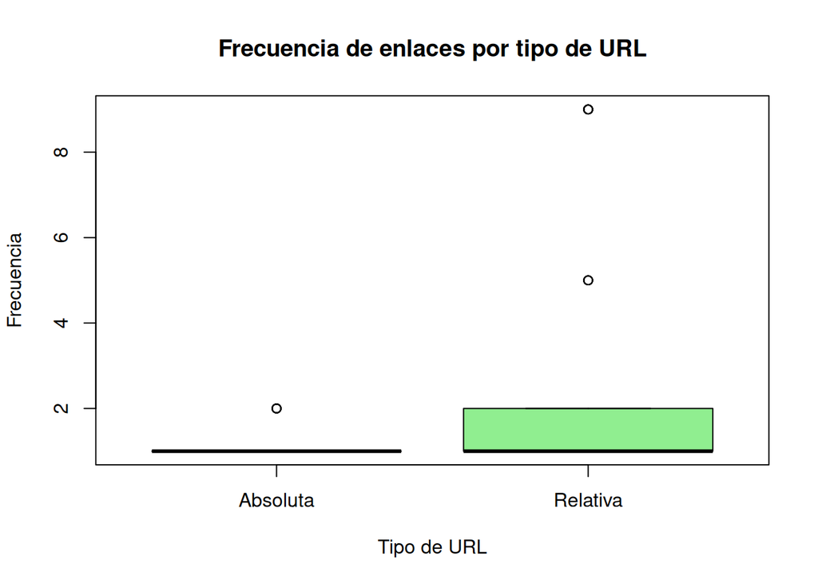

```r
# Clasificar URLs como absolutas o relativas
tabla_enlaces$tipo_url <- ifelse(
  grepl("^https?://", tabla_enlaces$enlace),
  "Absoluta",
  "Relativa"
)

# Gráfico para comparar frecuencias
boxplot(
  visto ~ tipo_url,
  data = tabla_enlaces,
  main = "Frecuencia de enlaces por tipo de URL",
  xlab = "Tipo de URL",
  ylab = "Frecuencia",
  col = c("skyblue", "lightgreen")
)
```

El diagrama de caja muestra la distribución de la frecuencia de aparición de enlaces según su tipo (absolutos y relativos).

Se observa que los enlaces relativos presentan una mayor variabilidad en su frecuencia, incluyendo valores atípicos más altos, lo que indica que algunos enlaces internos se repiten con mayor frecuencia dentro de la página.

Esto refleja el comportamiento típico de una página web, donde los enlaces internos (relativos) son más utilizados para la navegación dentro del sitio, mientras que los enlaces externos (absolutos) se emplean de forma más puntual.

## Pregunta 2: Un gráfico de barras indicando la suma de enlaces que apuntan a otros dominios o servicios (distinto a https://www.mediawiki.org en el caso de ejemplo) vs. la suma de los otros enlaces.

### Aquí queremos distinguir enlaces que apuntan a mediawiki versus el resto. Sabemos que las URLs relativas ya apuntan dentro, por lo tanto hay que analizar las URLs absolutas y comprobar que apunten a https://www.mediawiki.org.

Para este gráfico se clasificaron los enlaces en dos grandes grupos:

- **MediaWiki**: enlaces internos, incluyendo tanto las URLs relativas como las URLs absolutas que apuntan al dominio [`https://www.mediawiki.org`](https://www.mediawiki.org)
- **Externo**: enlaces absolutos que apuntan a otros dominios o servicios distintos

Posteriormente, se calculó la suma de apariciones (`visto`) para cada categoría, obteniendo así una medida agregada del peso de los enlaces internos frente a los externos dentro de la página analizada.

Se utilizó `na.rm = TRUE` al realizar la suma para evitar que valores faltantes (`NA`) afectaran el resultado final.

```r
# Clasificar enlaces como internos (MediaWiki) o externos
tabla_enlaces$tipo_dominio <- ifelse(
  is.na(tabla_enlaces$enlace),
  NA,
  ifelse(
    grepl("^https?://", tabla_enlaces$enlace),
    ifelse(grepl("^https?://www\\.mediawiki\\.org", tabla_enlaces$enlace),
           "MediaWiki",
           "Externo"),
    "MediaWiki"
  )
)

# Verificación rápida
table(tabla_enlaces$tipo_dominio, useNA = "ifany")
```

```
##
##   Externo MediaWiki
##        38       156
```

```r
# Sumar la frecuencia de aparición por categoría
suma_dominios <- tapply(
  tabla_enlaces$visto,
  tabla_enlaces$tipo_dominio,
  sum,
  na.rm = TRUE
)

suma_dominios
```

```
##   Externo MediaWiki
##        44       264
```

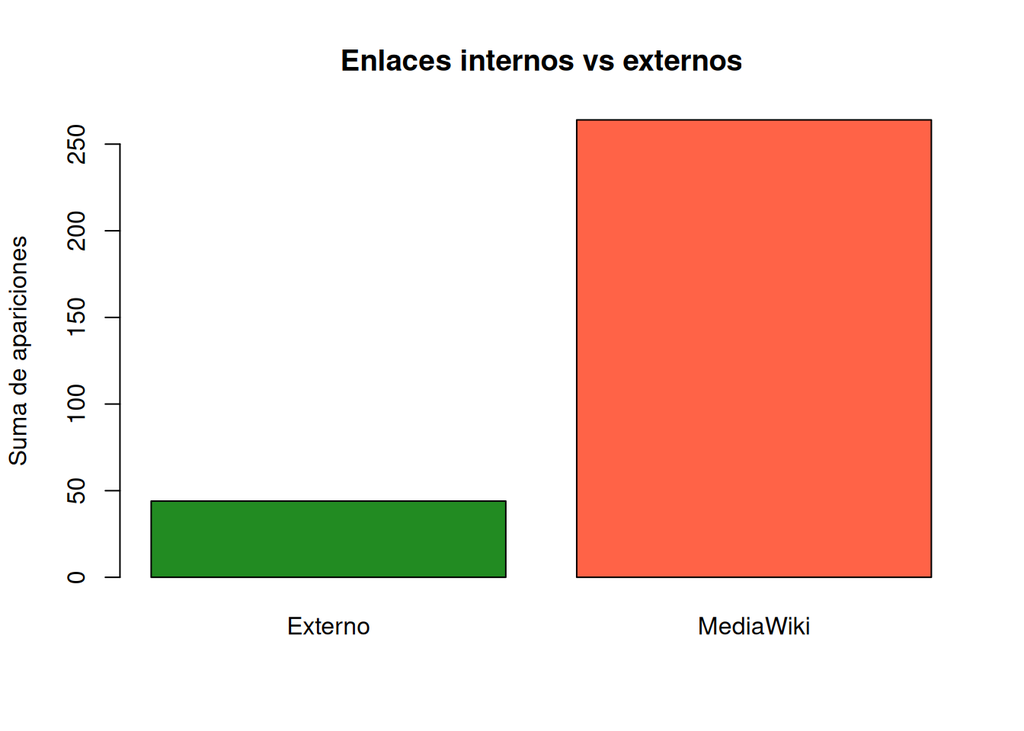

```r
# Gráfico de barras con base R
barplot(
  suma_dominios,
  main = "Enlaces internos vs externos",
  ylab = "Suma de apariciones",
  col = c("forestgreen", "tomato")
)
```

**Versión con qplot**

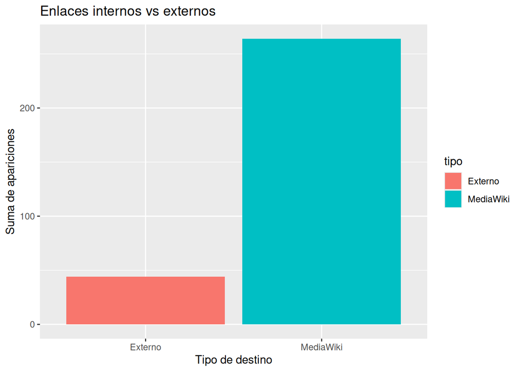

```r
library(ggplot2)

df_barras <- data.frame(
  tipo = names(suma_dominios),
  total = as.numeric(suma_dominios)
)

qplot(
  x = tipo,
  y = total,
  data = df_barras,
  geom = "col",
  fill = tipo
) +
  labs(
    title = "Enlaces internos vs externos",
    x = "Tipo de destino",
    y = "Suma de apariciones"
  )
```

Para distinguir entre enlaces internos y externos se utilizó un gráfico de puntos (`dotchart`) en lugar de un gráfico de barras. Este tipo de representación permite comparar de forma directa la suma de apariciones de enlaces que apuntan al dominio de MediaWiki frente a aquellos que dirigen a dominios externos.

Las URLs relativas se consideraron internas por definición, mientras que en las URLs absolutas se comprobó explícitamente si pertenecían o no al dominio [`https://www.mediawiki.org`](https://www.mediawiki.org).

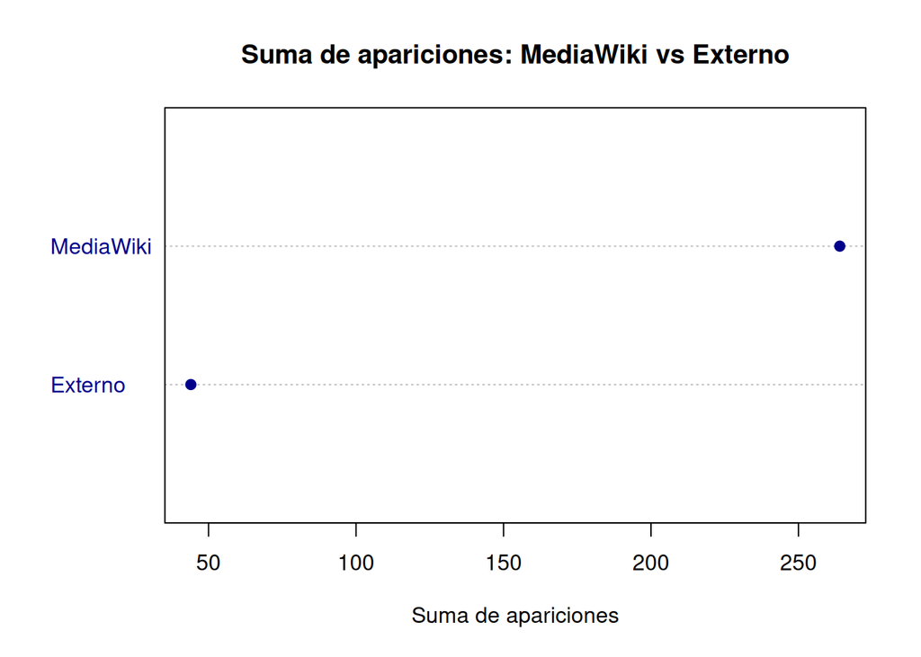

```r
# Clasificar enlaces como internos (MediaWiki) o externos
tabla_enlaces$tipo_dominio <- ifelse(
  is.na(tabla_enlaces$enlace),
  NA,
  ifelse(
    grepl("^https?://", tabla_enlaces$enlace),
    ifelse(
      grepl("^https?://www\\.mediawiki\\.org", tabla_enlaces$enlace),
      "MediaWiki",
      "Externo"
    ),
    "MediaWiki"
  )
)

# Sumar la frecuencia de aparición por categoría
suma_dominios <- tapply(
  tabla_enlaces$visto,
  tabla_enlaces$tipo_dominio,
  sum,
  na.rm = TRUE
)

dotchart(
  suma_dominios,
  main = "Suma de apariciones: MediaWiki vs Externo",
  xlab = "Suma de apariciones",
  pch = 19,
  color = "darkblue"
)
```

## Pregunta 3: Un gráfico de tarta (pie chart) indicando los porcentajes de Status de nuestro análisis.

### Por ejemplo, si hay 6 enlaces con status “200” y 4 enlaces con status “404”, la tarta mostrará un 60% con la etiqueta “200” y un 40% con la etiqueta “404”. Este gráfico lo uniremos a los anteriores. El objetivo final es obtener una imagen que recopile los gráficos generados.

Para completar la infografía del análisis, se generó un gráfico de tarta con la distribución porcentual de los códigos de estado HTTP obtenidos durante la validación de enlaces.

En primer lugar, se calculó la frecuencia de cada valor de `status` mediante `table()`. A continuación, se transformaron dichas frecuencias en porcentajes utilizando `prop.table()`, lo que permitió etiquetar cada sector del gráfico con su código HTTP y su peso relativo dentro del conjunto total de enlaces analizados.

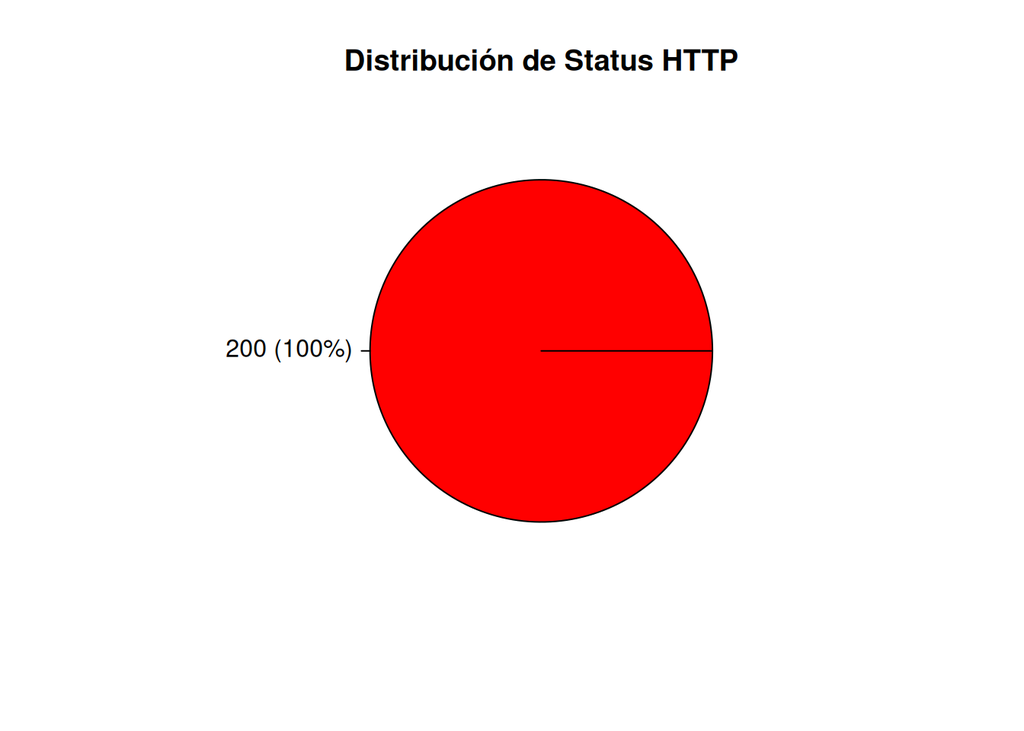

```r
# Tabla de frecuencias de status
tabla_status <- table(tabla_enlaces$status, useNA = "ifany")

# Porcentajes
porcentaje_status <- prop.table(tabla_status) * 100

# Etiquetas para el pie chart
etiquetas_status <- paste0(
  names(tabla_status),
  " (",
  round(porcentaje_status, 1),
  "%)"
)

# Gráfico de tarta
pie(
  tabla_status,
  labels = etiquetas_status,
  main = "Distribución de Status HTTP",
  col = rainbow(length(tabla_status))
)
```

Para representar la distribución porcentual de los códigos de estado HTTP se optó por un gráfico de puntos en lugar de un gráfico de tarta. Esta elección facilita la comparación visual entre categorías y evita las limitaciones habituales de los gráficos circulares cuando existen pocas o muchas diferencias entre proporciones.

El gráfico muestra el peso relativo de cada código de estado dentro del conjunto total de enlaces analizados.

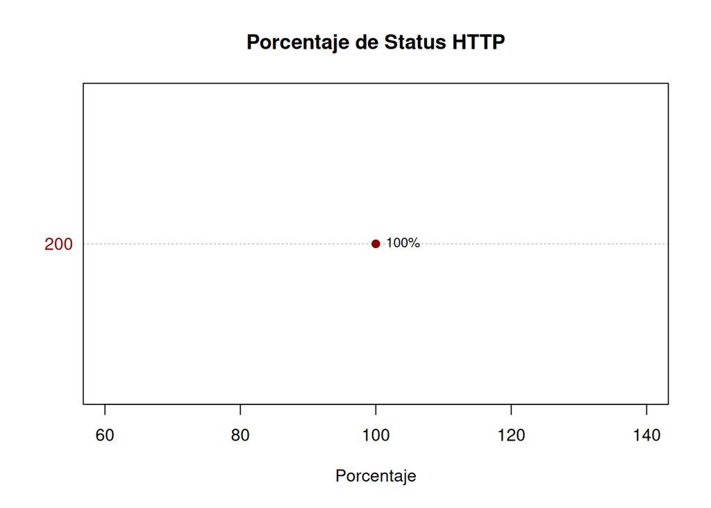

```r
# Tabla de frecuencias de status
tabla_status <- table(tabla_enlaces$status, useNA = "ifany")

# Porcentajes
porcentaje_status <- prop.table(tabla_status) * 100

dotchart(
  porcentaje_status,
  main = "Porcentaje de Status HTTP",
  xlab = "Porcentaje",
  pch = 19,
  color = "darkred"
)
text(
  x = porcentaje_status,
  y = seq_along(porcentaje_status),
  labels = paste0(round(porcentaje_status, 1), "%"),
  pos = 4,
  cex = 0.8
)
```

TODOS LOS GRÁFICOS JUNTOS

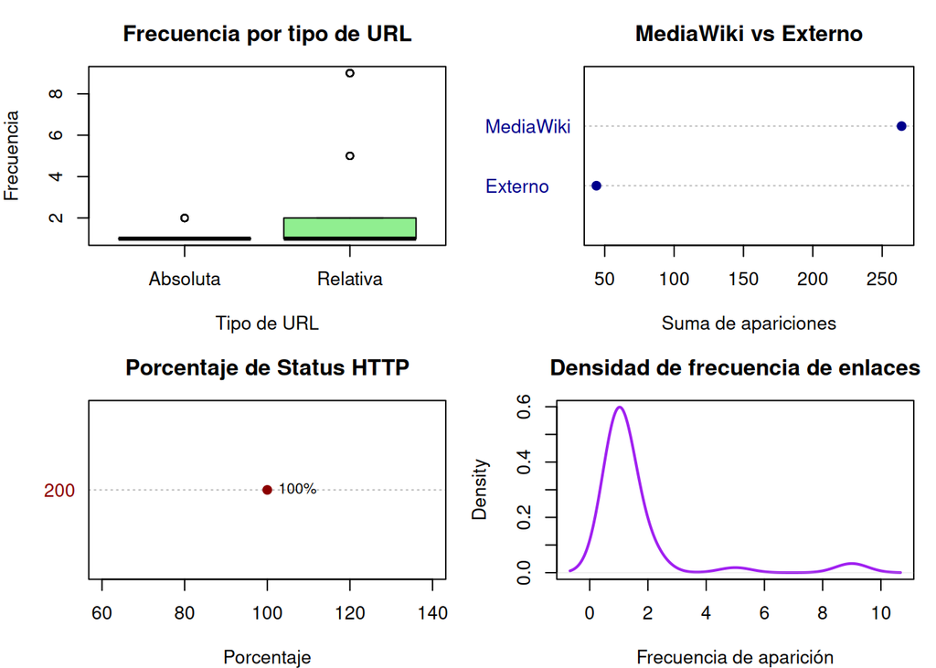

```r
# =========================
# PREPARACIÓN DE DATOS
# =========================

tabla_enlaces$tipo_url <- ifelse(
  grepl("^https?://", tabla_enlaces$enlace),
  "Absoluta",
  "Relativa"
)

tabla_enlaces$tipo_dominio <- ifelse(
  is.na(tabla_enlaces$enlace),
  NA,
  ifelse(
    grepl("^https?://", tabla_enlaces$enlace),
    ifelse(
      grepl("^https?://www\\.mediawiki\\.org", tabla_enlaces$enlace),
      "MediaWiki",
      "Externo"
    ),
    "MediaWiki"
  )
)

suma_dominios <- tapply(
  tabla_enlaces$visto,
  tabla_enlaces$tipo_dominio,
  sum,
  na.rm = TRUE
)

tabla_status <- table(tabla_enlaces$status, useNA = "ifany")
porcentaje_status <- prop.table(tabla_status) * 100

# =========================
# INFOGRAFÍA EN UNA SOLA FIGURA
# =========================

par(mfrow = c(2, 2), mar = c(4, 4, 3, 1))

# 1. Boxplot URLs absolutas vs relativas
boxplot(
  visto ~ tipo_url,
  data = tabla_enlaces,
  main = "Frecuencia por tipo de URL",
  xlab = "Tipo de URL",
  ylab = "Frecuencia",
  col = c("skyblue", "lightgreen")
)

# 2. Dotchart MediaWiki vs Externo
dotchart(
  suma_dominios,
  main = "MediaWiki vs Externo",
  xlab = "Suma de apariciones",
  pch = 19,
  color = "darkblue"
)
# 3. Dotchart de status HTTP
dotchart(
  porcentaje_status,
  main = "Porcentaje de Status HTTP",
  xlab = "Porcentaje",
  pch = 19,
  color = "darkred"
)
text(
  x = porcentaje_status,
  y = seq_along(porcentaje_status),
  labels = paste0(round(porcentaje_status, 1), "%"),
  pos = 4,
  cex = 0.8
)

# 4. Densidad de frecuencia de aparición
plot(
  density(tabla_enlaces$visto, na.rm = TRUE),
  main = "Densidad de frecuencia de enlaces",
  xlab = "Frecuencia de aparición",
  col = "purple",
  lwd = 2
)
```

```r
par(mfrow = c(1, 1))
```